# Mini Project

Melchizedek Ackah-Blay

2024-04-14

# Introduction

The research question for this analysis is: Does the number of days of poor physical health differ between males and females in the United States?

This research is important to study for several reasons. First and foremost, understanding disparities in health outcomes between different demographic groups is crucial for designing targeted interventions and policies. By investigating whether there is a difference in the number of days of poor physical health between males and females, we can identify potential areas where interventions may be needed to improve overall health outcomes. The Behavioral Risk Factor Surveillance System (BRFSS) data allows us to delve into the health-related behaviors and conditions of the U.S. population. By pinpointing disparities between males and females in terms of their reported number of days of poor physical health, public health officials can tailor interventions to address these differences. This can lead to more effective health promotion strategies, disease prevention efforts, and targeted healthcare services.

Health equity is a major concern in healthcare. If we find that one gender consistently reports more days of poor physical health than the other, it raises questions about access to healthcare, social determinants of health, and potential biases in health outcomes. This research can contribute to the broader conversation about health equity and the need to ensure that all individuals, regardless of gender, have equal opportunities for good health. Stakeholders The stakeholders for this research are diverse and encompass a range of groups: Public Helath Agencies, Healthcare Providers, and Policy Makers. Public Health Agencies are organizations responsible for public health policies and interventions will directly benefit from this research. They can use the findings to allocate resources effectively and target interventions to specific gender-related health needs. Healthcare Providers includ Doctors, nurses, and healthcare professionals. They use this information to guide their patient care practices. If there are gender differences in reported days of poor physical health, healthcare providers can be more vigilant in assessing and addressing these issues during patient visits. Policy Makers include legislators and policymakers. They can use this data to inform health policy decisions. Understanding the health disparities between genders can lead to the development of policies aimed at reducing these disparities and promoting better health outcomes for all.

The results of this analysis can have direct implications for patient care:

Screening and Assessment: Healthcare institutions can use this information to develop screening tools that are sensitive to gender-specific health needs. For example, if females are found to report more days of poor physical health, healthcare providers can include targeted questions during assessments to better capture these issues.

Tailored Interventions: Knowing that there may be differences in reported days of poor physical health between males and females, healthcare institutions can design interventions that are tailored to each gender’s needs. This could range from educational programs on lifestyle modifications to specific treatment protocols for certain conditions.

Health Education: Patient education materials can be developed with a gender-specific focus. If, for instance, females are reporting more days of poor physical health, educational materials can emphasize preventive measures and early detection for conditions that commonly affect women.

# Data Cleaning & Exploratory Data Analysis

```r
#load libraries
library(ggplot2)
library(questionr)
library(dplyr)
setwd("~/Desktop")

# Import the BRFSS.csv file
brfss_data <- read.csv("BRFSS.csv")

# Find the number of observations in the dataframe
num_observations <- nrow(brfss_data)

# Find the number of variables in the dataframe
num_variables <- ncol(brfss_data)

# Recode values of "Number of Days Physical Health Not Good" variable to NA
# Values to be recoded: None (value=88), Don’t know/Not sure (value=77), Refused (value=99)
brfss_data$PHYSHLTH[brfss_data$PHYSHLTH %in% c(88, 77, 99)] <- NA

# Check the recode was successful
cat("Check Recode - Unique Values in PHYSHLTH after recode:", unique(brfss_data$PHYSHLTH), "\n")
```

```
## Check Recode - Unique Values in PHYSHLTH after recode: 3 30 NA 2 10 4 28 5 7 1 20 9 6 15 14 18 21 29 25 16 26 27 8 23 12 17
```

```r
# Create a new variable SEX2 based on SEX variable (1 = Male, 2 = Female)
brfss_data$SEX2 <- ifelse(brfss_data$SEX == 1, "Male", "Female")

# Check the creation of SEX2
table(brfss_data$SEX, brfss_data$SEX2)
```

```
##
##     Female Male
##   1      0  996
##   2   2264    0
```

```r
# Find the mean of "Number of Days Physical Health Not Good" variable after recode
mean_physhlth <- mean(brfss_data$PHYSHLTH, na.rm = TRUE)

# Find the percentages of males and females in the data
gender_percentages <- table(brfss_data$SEX2) / nrow(brfss_data) * 100
```

Narrative:

The data used for this analysis is from the “Behavioral Risk Factor Surveillance System (BRFSS)” survey conducted in 2010. The dataset is in a CSV format and contains health-related survey responses from U.S. residents regarding their behaviors, chronic conditions, and use of preventive services. Data Cleaning Summary:

Recoding “Number of Days Physical Health Not Good” (PHYSHLTH) Variable: Values indicating “None” (88), “Don’t know/Not sure” (77), and “Refused” (99) were recoded to NA. The recode was successfully verified by checking the unique values of PHYSHLTH after recoding.

Creation of “SEX2” Variable: A new variable “SEX2” was created based on the existing “SEX” variable, where 1 represents “Male” and 2 represents “Female”. The creation of “SEX2” was verified by comparing the frequencies of the original “SEX” variable with the newly created “SEX2”.

Summary Statistics: Number of Observations: Approximately 69.45% of individuals in this dataset were female, Approximately 30.55%% of individuals in this dataset were male.

Conclusion

The dataset used for this analysis was the BRFSS survey data from 2010, containing responses from 3,260 individuals across 397 variables. After cleaning the data by recoding “Number of Days Physical Health Not Good” values indicating “None”, “Don’t know/Not sure”, and “Refused” to NA, the mean number of days of poor physical health was found to be 15.04811 days. The dataset was largly female (gender wise) approximately 69% females and 31% males. These cleaned and summarized data will now be used for further analysis on whether the reported number of days of poor physical health differs between males and females.

#Data Visualization

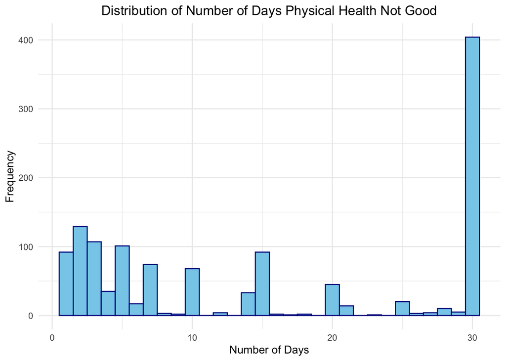

```r
# Set theme for ggplot
theme_set(theme_minimal())

# Create histogram for "Number of Days Physical Health Not Good" variable
ggplot(data = brfss_data, aes(x = PHYSHLTH)) +
  geom_histogram(binwidth = 1, fill = "skyblue", color = "darkblue") +
  labs(title = "Distribution of Number of Days Physical Health Not Good",
       x = "Number of Days",
       y = "Frequency") +
  theme(plot.title = element_text(hjust = 0.5))
```

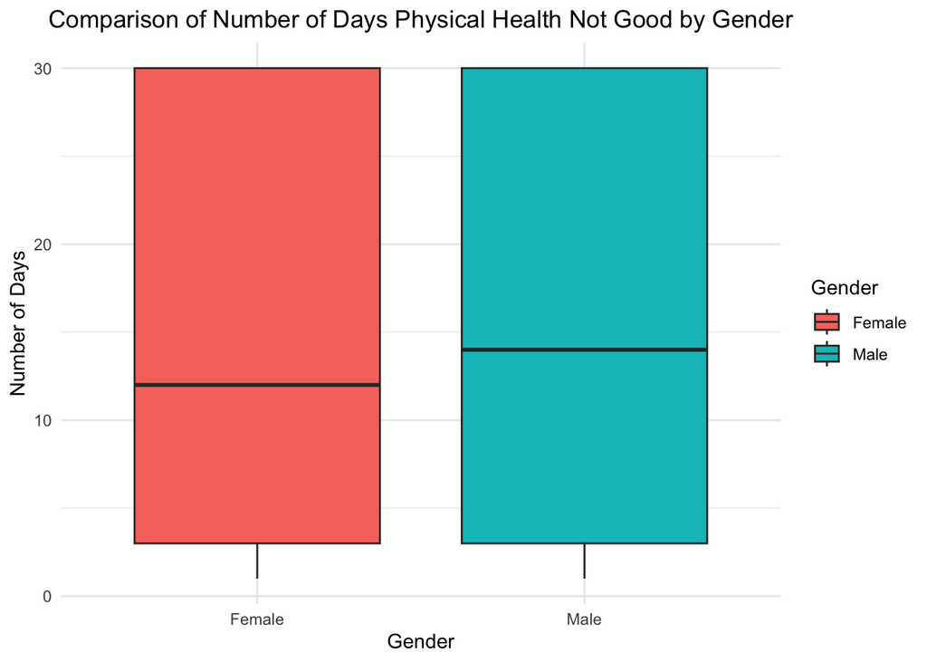

```r
# Create boxplot for "Number of Days Physical Health Not Good" by SEX2
ggplot(data = brfss_data, aes(x = SEX2, y = PHYSHLTH, fill = SEX2)) +
  geom_boxplot() +
  labs(title = "Comparison of Number of Days Physical Health Not Good by Gender",
       x = "Gender",
       y = "Number of Days",
       fill = "Gender") +
  theme(plot.title = element_text(hjust = 0.5))
```

Narrative:

Median (Line Inside Box): The median number of days of poor physical health for males is slightly higher than for females. This indicates that, on average, males in the dataset reported higher days of poor physical health than females.

Interquartile Range (Box): The box represents the interquartile range (IQR), which is the middle 50% of the data. For both males and females, the IQR is similar in width, suggesting a similar spread of data within the middle 50%.

Overall Difference: The notable difference between males and females is in the median: with males having a slightly higher median. I speculate that in the number of males were higher, it would even out.

#Hypothesis Test

Narrative:

Null Hypothesis (H0): The null hypothesis for this test is that there is no difference in the mean number of days of poor physical health between males and females in the population.

Alternative Hypothesis (H1): The alternative hypothesis is that there is a difference in the mean number of days of poor physical health between males and females in the population. I

This two-sided alternative hypothesis tests if the mean number of days of poor physical health is different between males and females, without specifying the direction of the difference.

Alpha Level: The alpha level (significance level) is typically set at 0.05 for hypothesis tests. This means we are willing to accept a 5% chance of incorrectly rejecting the null hypothesis if it is true.

Type of Test: The type of test conducted here is a two-sided t-test. This is appropriate because we are interested in determining if there is a significant difference in the mean number of days of poor physical health between males and females, without assuming whether one group is higher or lower than the other.

# Conclusion

Future Research: To build on this analysis, future research could explore other factors that might contribute to differences in reported days of poor physical health. This could include investigating lifestyle factors, access to healthcare, socioeconomic status, and other social determinants of health. Additionally, examining how these differences may vary across different age groups or regions could provide a more comprehensive understanding of the factors at play. Longitudinal studies could also track changes over time and how they impact reported health outcomes between genders.